# Let's start from an example of square sum calculation

We know there are many packages can be used to calculation the square sum of a list. Here we just want to introduce the example of using multiprocessing technologies in python.

```python
def square_list(input_list):
    square_sum = 0
    for i in input_list:
        square_sum += i ** 2
    return square_sum
```

```python
import numpy as np
np.random.seed(2)
input_list = np.random.randn(1000)
print (square_list(input_list))
%timeit square_list(input_list)
```

```
1011.0526181081407
371 µs ± 3.99 µs per loop (mean ± std. dev. of 7 runs, 1000 loops each)
```

## Now we firstly test the example of multiprocessing package

```python
def square(list_element):
    return list_element ** 2
```

```python
from multiprocessing import Pool
import numpy as np
np.random.seed(2)
input_list = np.random.randn(1000)
p = Pool(4)
print (sum(p.map(square, input_list)))
%timeit sum(p.map(square, input_list))
```

```
1011.0526181081407
3.13 ms ± 108 µs per loop (mean ± std. dev. of 7 runs, 100 loops each)
```

## It may be confused that why we don't get any acceration in this process. Maybe because this problem doesn't fit for multiprocessing? Then we consider the loops in this problem and get an overall result.

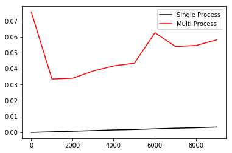

```python
from multiprocessing import Pool
import time
import numpy as np
import matplotlib.pyplot as plt
def square_list(input_list):
    square_sum = 0
    for i in input_list:
        square_sum += i ** 2
    return square_sum
def square(list_element):
    return list_element ** 2
list_lengths = range(10, 10000, 1000)
plt.figure()
time_sg = []
time_mp = []
for list_length in list_lengths:
    np.random.seed(2)
    input_list = np.random.randn(list_length)
    time1 = time.time()
    square_sum = square_list(input_list)
    time2 = time.time()
    p = Pool(8)
    square_sum = sum(p.map(square, input_list))
    time3 = time.time()
    time_sg.append(time2 - time1)
    time_mp.append(time3 - time2)
plt.plot(list_lengths, time_sg, color = 'black', label = 'Single Process')
plt.plot(list_lengths, time_mp, color = 'red', label = 'Multi Process')
plt.legend()
plt.show()
```

## But a good news is that all the CPUs are used

The situation of single processing:

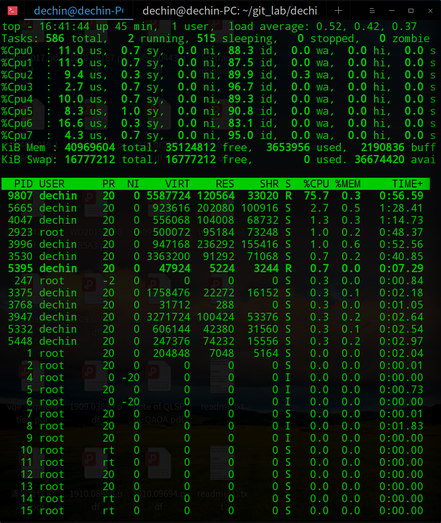

And the situation of multi processing are very different you can see:

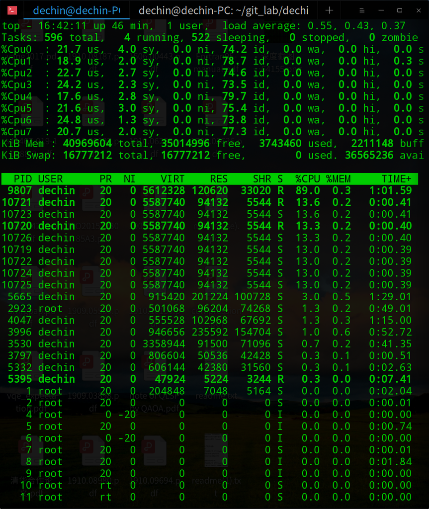

What's more, you can control the process number you want to run your task by just changing the Pool number. For example if the Pool number is restricted to 4, then the situation would be like:

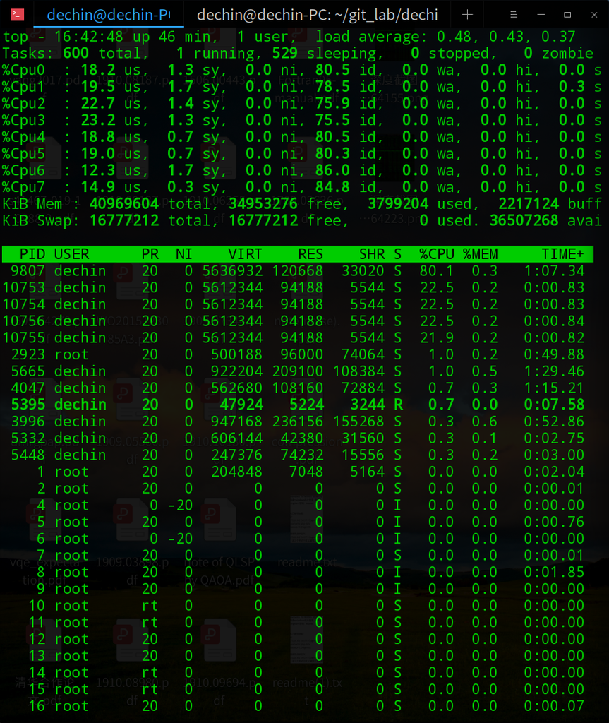

## Now let's test a more complicated example

```python
def pi_sum(input_list):
    this_sum = 0
    for i in input_list:
        pi_i = 1
        for j in range(int(i)):
            pi_i *= j + 1
        this_sum += pi_i
    return this_sum
import numpy as np
np.random.seed(3)
input_list = np.random.randn(100) + 1000
print (pi_sum(input_list))
%timeit pi_sum(input_list)
```

```
410050337953179211863434930460480849022304296448033376790322…
21.9 ms ± 667 µs per loop (mean ± std. dev. of 7 runs, 10 loops each)
```

```python
def pi_mp(input_element):
    pi_i = 1
    for j in range(int(input_element)):
        pi_i *= j + 1
    return pi_i
import numpy as np
from multiprocessing import Pool
np.random.seed(3)
input_list = np.random.randn(100) + 1000
p = Pool(8)
print (sum(p.map(pi_mp, input_list)))
%timeit sum(p.map(pi_mp, input_list))
```

```
410050337953179211863434930460480849022304296448033376790322…
7.43 ms ± 161 µs per loop (mean ± std. dev. of 7 runs, 100 loops each)
```

## For now you can see there is an obviously acceration toward this problem. But why there is no 8 times acceration even I have set the Pool number to 8?

```python
def pi_sum(input_list):
    this_sum = 0
    for i in input_list:
        pi_i = 1
        for j in range(int(i)):
            pi_i *= j + 1
        this_sum += pi_i
    return this_sum
import numpy as np
np.random.seed(3)
input_list = np.random.randn(100) + 10000
%timeit pi_sum(input_list)
```

```
1.5 s ± 24.1 ms per loop (mean ± std. dev. of 7 runs, 1 loop each)
```

```python
def pi_mp(input_element):
    pi_i = 1
    for j in range(int(input_element)):
        pi_i *= j + 1
    return pi_i
import numpy as np
from multiprocessing import Pool
np.random.seed(3)
input_list = np.random.randn(100) + 10000
p = Pool(8)
%timeit sum(p.map(pi_mp, input_list))
```

```
470 ms ± 8 ms per loop (mean ± std. dev. of 7 runs, 1 loop each)
```

## Continue to add larger numbers into input list

```python
def pi_sum(input_list):
    this_sum = 0
    for i in input_list:
        pi_i = 1
        for j in range(int(i)):
            pi_i *= j + 1
        this_sum += pi_i
    return this_sum
import numpy as np
np.random.seed(3)
input_list = np.random.randn(20) + 30000
%timeit pi_sum(input_list)
```

```
2.89 s ± 24.3 ms per loop (mean ± std. dev. of 7 runs, 1 loop each)
```

```python
def pi_mp(input_element):
    pi_i = 1
    for j in range(int(input_element)):
        pi_i *= j + 1
    return pi_i
import numpy as np
from multiprocessing import Pool
np.random.seed(3)
input_list = np.random.randn(20) + 30000
p = Pool(8)
%timeit sum(p.map(pi_mp, input_list))
```

```
832 ms ± 10.8 ms per loop (mean ± std. dev. of 7 runs, 1 loop each)
```

```python
def pi_sum(input_list):
    this_sum = 0
    for i in input_list:
        pi_i = 1
        for j in range(int(i)):
            pi_i *= j + 1
        this_sum += pi_i
    return this_sum
import numpy as np
np.random.seed(3)
input_list = np.random.randn(20) + 50000
%timeit pi_sum(input_list)
```

```
8.61 s ± 154 ms per loop (mean ± std. dev. of 7 runs, 1 loop each)
```

```python
def pi_mp(input_element):
    pi_i = 1
    for j in range(int(input_element)):
        pi_i *= j + 1
    return pi_i
import numpy as np
from multiprocessing import Pool
np.random.seed(3)
input_list = np.random.randn(20) + 50000
p = Pool(8)
%timeit sum(p.map(pi_mp, input_list))
```

```
3.13 s ± 441 ms per loop (mean ± std. dev. of 7 runs, 1 loop each)
```

```python
def pi_sum(input_list):
    this_sum = 0
    for i in input_list:
        pi_i = 1
        for j in range(int(i)):
            pi_i *= j + 1
        this_sum += pi_i
    return this_sum
import numpy as np
np.random.seed(3)
input_list = np.random.randn(8) + 70000
%timeit pi_sum(input_list)
```

```
7.04 s ± 136 ms per loop (mean ± std. dev. of 7 runs, 1 loop each)
```

```python
def pi_mp(input_element):
    pi_i = 1
    for j in range(int(input_element)):
        pi_i *= j + 1
    return pi_i
import numpy as np
from multiprocessing import Pool
np.random.seed(3)
input_list = np.random.randn(8) + 70000
p = Pool(8)
%timeit sum(p.map(pi_mp, input_list))
```

```
2.58 s ± 351 ms per loop (mean ± std. dev. of 7 runs, 1 loop each)
```

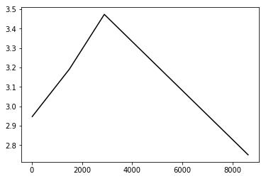

```python
time1 = [21.9, 1500, 2890, 8610]
time2 = [7.43, 470, 832, 3130]
rate = []
for i in range(len(time1)):
    rate.append(time1[i] / time2[i])
import matplotlib.pyplot as plt
plt.figure()
plt.plot(time1, rate, color = 'black', label = 'rate')
plt.show()
```

# A summary

There is not alway accerations by using multiprocessing, especially those cases don't need a lot of calculations but need a lot of communications. These cases are bad for multiprocessing.